# Soluciones P1: Introducción a R y ggplot2

**Soluciones P1:**  
Introducción a `R` y `ggplot2`

Marta Coronado Zamora Septiembre 2026

### Actividad 1.1

Fijamos el directorio de trabajo (la ruta depende de cada ordenador) y lo comprobamos.

```r
setwd("C:/Users/usuario/Desktop/Bioestadistica")
getwd()
```

### Actividad 1.2

Leemos el CSV directamente desde la URL.

```r
expressionData <- read.csv("https://raw.githubusercontent.com/marta-coronado/biostatistics-uab/refs/heads/main/P/1/data/GSE68849_expression.csv")
```

### Actividad 1.3

Tabla de 100 filas y 4 columnas: sujeto, tratamiento (control/influenza), gen y nivel de expresión.

```r
head(expressionData)
```

```
##      subject treatment  gene expression_level
## 1 GSM1684095   control IFNA5         83.12937
## 2 GSM1684096 influenza IFNA5      10096.47000
## 3 GSM1684097   control IFNA5         97.80374
## 4 GSM1684098 influenza IFNA5       8180.98900
## 5 GSM1684099   control IFNA5         81.70878
## 6 GSM1684100 influenza IFNA5       7054.90200
```

```r
dim(expressionData)
```

```
## [1] 100   4
```

```r
View(expressionData)
```

### Actividad 1.4

```r
str(expressionData)
```

```
## 'data.frame':    100 obs. of  4 variables:
##  $ subject         : chr  "GSM1684095" "GSM1684096" "GSM1684097" "GSM1684098" ...
##  $ treatment       : chr  "control" "influenza" "control" "influenza" ...
##  $ gene            : chr  "IFNA5" "IFNA5" "IFNA5" "IFNA5" ...
##  $ expression_level: num  83.1 10096.5 97.8 8181 81.7 ...
```

| Variable | Tipo de variable | Tipo específico | Observaciones |
| --- | --- | --- | --- |
| *Subject* | Cualitativa | Nominal | Identificador de la muestra (10 sujetos) |
| *Treatment* | Cualitativa | Nominal | 2 categorías: control / influenza |
| *Gene* | Cualitativa | Nominal | 10 genes |
| *Expression level* | Cuantitativa | Continua | Nivel de expresión (`num`) |

### Actividad 1.5

```r
mean(expressionData$expression_level)
```

```
## [1] 3947.509
```

```r
median(expressionData$expression_level)
```

```
## [1] 131.8218
```

```r
sd(expressionData$expression_level)
```

```
## [1] 7210.434
```

La media (≈ 3947) es muy superior a la mediana (≈ 132): la distribución está muy sesgada a la derecha por unos pocos valores muy altos.

### Actividad 1.6

Hay 10 genes distintos.

```r
expressionData %>%
  select(gene) %>%
  distinct() %>%
  count()
```

```
##    n
## 1 10
```

### Actividad 1.7

```r
expressionData_GSM1684096 <- expressionData %>%
  filter(subject == "GSM1684096")

expressionData_GSM1684096
```

```
##       subject treatment    gene expression_level
## 1  GSM1684096 influenza   IFNA5       10096.4700
## 2  GSM1684096 influenza  IFNA13       18974.1600
## 3  GSM1684096 influenza   IFNA2       24029.1100
## 4  GSM1684096 influenza   SPIN1         107.8756
## 5  GSM1684096 influenza  ZNF451         432.3180
## 6  GSM1684096 influenza  IFNA16       23060.4700
## 7  GSM1684096 influenza  RASSF1         353.3666
## 8  GSM1684096 influenza   IFNW1        8665.8660
## 9  GSM1684096 influenza    MSR1         108.8238
## 10 GSM1684096 influenza MIR1976         106.2709
```

### Actividad 1.8

El sujeto `GSM1684104` es del grupo infectado; filtramos por gen y sujeto y nos quedamos con la expresión.

```r
expressionData %>%
  filter(gene == "IFNA5", subject == "GSM1684104") %>%
  select(expression_level)
```

```
##   expression_level
## 1         9397.261
```

### Actividad 1.9

La expresión media es mucho mayor en el grupo infectado.

```r
expressionData %>%
  group_by(treatment) %>%
  summarize(media = mean(expression_level))
```

```
## # A tibble: 2 × 2
##   treatment media
##   <chr>     <dbl>
## 1 control    156.
## 2 influenza 7739.
```

### Actividad 1.10

```r
expressionData <- expressionData %>%
  mutate(expression_category = case_when(
    expression_level < 10 ~ "bajo",
    expression_level >= 10 & expression_level < 100 ~ "moderado",
    expression_level >= 100 & expression_level < 1000 ~ "alto",
    expression_level >= 1000 ~ "muy alto"
  ))

head(expressionData)
```

```
##      subject treatment  gene expression_level expression_category
## 1 GSM1684095   control IFNA5         83.12937            moderado
## 2 GSM1684096 influenza IFNA5      10096.47000            muy alto
## 3 GSM1684097   control IFNA5         97.80374            moderado
## 4 GSM1684098 influenza IFNA5       8180.98900            muy alto
## 5 GSM1684099   control IFNA5         81.70878            moderado
## 6 GSM1684100 influenza IFNA5       7054.90200            muy alto
```

### Actividad 1.11 (opcional)

Los genes con expresión `muy alto` solo aparecen en el grupo de influenza.

```r
expressionData %>%
  filter(expression_category == "muy alto") %>%
  count(treatment)
```

```
##   treatment  n
## 1 influenza 25
```

### Actividad 1.12

**Paso 1.** Heatmap básico: sujetos en el eje `x`, genes en el eje `y` y color según `log(expression_level)`.

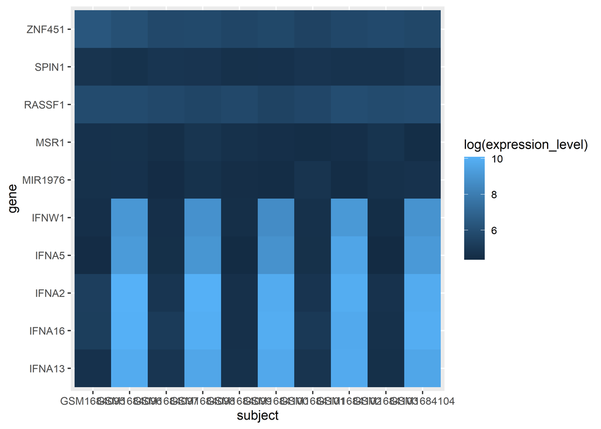

```r
exp.heatmap <- ggplot(data = expressionData,
                      mapping = aes(x = subject,
                                    y = gene,
                                    fill = log(expression_level))) +
  geom_tile()

exp.heatmap
```

**Paso 2.** Títulos de los ejes y etiquetas del eje `x` giradas 45°.

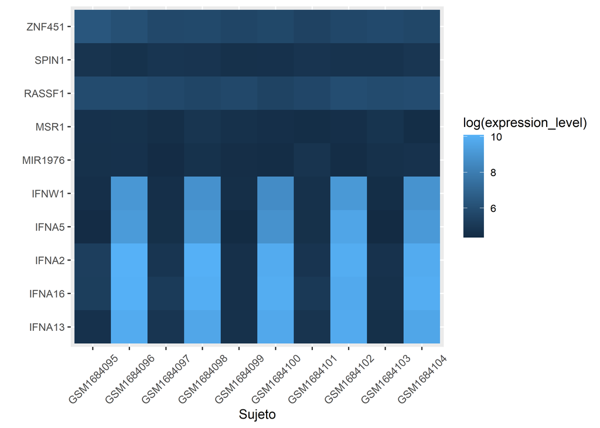

```r
exp.heatmap <- exp.heatmap +
  labs(x = "Sujeto", y = "") +
  theme(axis.text.x = element_text(angle = 45, vjust = 0.5))

exp.heatmap
```

Separamos control e infectados con `facet_grid()`; `scales` y `space` eliminan las columnas vacías.

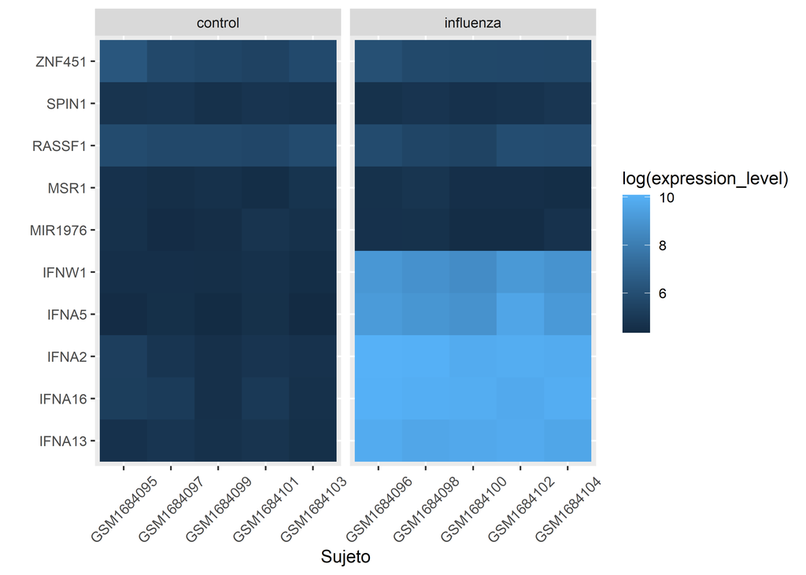

```r
exp.heatmap <- exp.heatmap +
  facet_grid(. ~ treatment, scales = "free_x", space = "free_x")

exp.heatmap
```

Escala de color `viridis`.

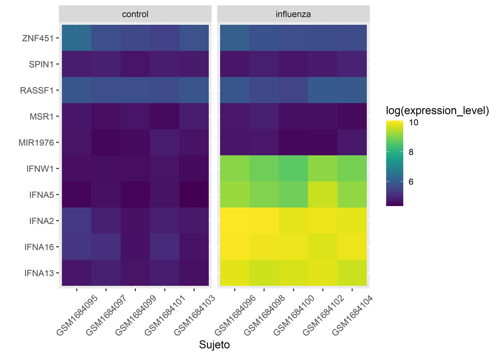

```r
library(viridis)
exp.heatmap <- exp.heatmap +
  scale_fill_viridis()

exp.heatmap
```

**¿Qué genes están sobreexpresados en el grupo infectado?**

Los cinco interferones de tipo I: **IFNA13, IFNA16, IFNA2, IFNA5 e IFNW1**. Su expresión es unas 100 veces mayor en las células infectadas, lo que concuerda con la respuesta antiviral de las células dendríticas plasmocitoides. El resto de genes (MIR1976, MSR1, RASSF1, SPIN1, ZNF451) no cambian entre grupos.